# MSDS692 Data Science Practicum Project

Topic: Forecasting Electricity Demand with Time Series

Date: 6JUNE2022

Author: Olumide Aluko

Purpose: The project aims to generate a forecasting model capable of predicting the next day's energy demand at the hourly level by accurately predicting monthly electricity demand.

Dataset Source: https://raw.githubusercontent.com/JoaquinAmatRodrigo/skforecast/master/'+'data/vic_elec.csv'

# Problem Statement:

A time series with electricity demand (Mega Watts) for the state of Victoria (Australia) from 2011-12-31 to 2014-12-31 is available. Demand for electricity in Australia has been in the spotlight for the general population due to the recently increasing price. Still, forecasts of the electricity demand have been expected to decrease due to various factors. The project aims to generate a forecasting model capable of predicting the next day's energy demand at the hourly level by accurately predicting monthly electricity demand. The proposed project design will be achieved using a time series forecasting with scikit-learn regressors

# Data Source

The data used in this document were obtained from the R tsibbledata package but i download it from GitGub for this project. The dataset contains 5 columns and 52,608 complete records. The information in each column is:

Time: date and time of the record.

Date: date of the record.

Demand: electricity demand (MW).

Temperature: temperature in Melbourne, capital of the state of Victoria.

Holiday: indicator if the day is a public holiday.

# Import Libraries:

```python
# Data manipulation
# ==============================================================================
import numpy as np
import pandas as pd

# Plots
# ==============================================================================
import matplotlib.pyplot as plt
import seaborn as sns
%matplotlib inline
from statsmodels.graphics.tsaplots import plot_acf
from statsmodels.graphics.tsaplots import plot_pacf
plt.style.use('fivethirtyeight')

# Modelling and Forecasting
# ==============================================================================
from sklearn.linear_model import Ridge
from lightgbm import LGBMRegressor
from sklearn.pipeline import make_pipeline
from sklearn.preprocessing import StandardScaler
from sklearn.metrics import mean_absolute_error
from skforecast.ForecasterAutoreg import ForecasterAutoreg
from skforecast.ForecasterAutoregMultiOutput import ForecasterAutoregMultiOutput
from skforecast.model_selection import grid_search_forecaster
from skforecast.model_selection import backtesting_forecaster

# Warnings configuration
# ==============================================================================
import warnings
warnings.filterwarnings('ignore')
```

```python
# Data download
# ==============================================================================
data = pd.read_csv('victoria_electricity.csv', sep=',')
data.info()
```

```
<class 'pandas.core.frame.DataFrame'>
RangeIndex: 52608 entries, 0 to 52607
Data columns (total 5 columns):
 #   Column       Non-Null Count  Dtype
---  ------       --------------  -----
 0   Time         52608 non-null  object
 1   Demand       52608 non-null  float64
 2   Temperature  52608 non-null  float64
 3   Date         52608 non-null  object
 4   Holiday      52608 non-null  bool
dtypes: bool(1), float64(2), object(2)
memory usage: 1.7+ MB
```

```python
len(pd.date_range(start="2011-12-31", end="2014-12-31"))
```

```
1097
```

No missing values, and 3 years of data to enjoy :)

Let's compute some date features and start the intereating part of the analysis

```python
# Data preparation
# ==============================================================================
data = data.copy()
data['Time'] = pd.to_datetime(data['Time'], format='%Y-%m-%dT%H:%M:%SZ')
data = data.set_index('Time')
data = data.asfreq('30min')
data = data.sort_index()
data.head(5)
```

| Time | Demand | Temperature | Date | Holiday |
| --- | --- | --- | --- | --- |
| 2011-12-31 13:00:00 | 4382.825174 | 21.40 | 2012-01-01 | True |
| 2011-12-31 13:30:00 | 4263.365526 | 21.05 | 2012-01-01 | True |
| 2011-12-31 14:00:00 | 4048.966046 | 20.70 | 2012-01-01 | True |
| 2011-12-31 14:30:00 | 3877.563330 | 20.55 | 2012-01-01 | True |
| 2011-12-31 15:00:00 | 4036.229746 | 20.40 | 2012-01-01 | True |

```python
# Verify that a temporary index is complete
# ==============================================================================
(data.index == pd.date_range(start=data.index.min(),
                              end=data.index.max(),
                              freq=data.index.freq)).all()
```

```
True
```

```python
print(f"Number of rows with missing values: {data.isnull().any(axis=1).mean()}")
```

```
Number of rows with missing values: 0.0
```

```python
# Fill gaps in a temporary index
# ==============================================================================
# data.asfreq(freq='30min', fill_value=np.nan)
```

For the 11:00 average value, the 11:00 point value is not included because, in reality, the value is not yet available at that exact time.

```python
# Aggregating in 1H intervals
# ==============================================================================
# The Date column is eliminated so that it does not generate an error when aggregating.
# The Holiday column does not generate an error since it is Boolean and is treated as 0-1.
data = data.drop(columns='Date')
data = data.resample(rule='H', closed='left', label ='right').mean()
data
```

| Time | Demand | Temperature | Holiday |
| --- | --- | --- | --- |
| 2011-12-31 14:00:00 | 4323.095350 | 21.225 | True |
| 2011-12-31 15:00:00 | 3963.264688 | 20.625 | True |
| 2011-12-31 16:00:00 | 3950.913495 | 20.325 | True |
| 2011-12-31 17:00:00 | 3627.860675 | 19.850 | True |
| 2011-12-31 18:00:00 | 3396.251676 | 19.025 | True |
| ... | ... | ... | ... |
| 2014-12-31 09:00:00 | 4069.625550 | 21.600 | False |
| 2014-12-31 10:00:00 | 3909.230704 | 20.300 | False |
| 2014-12-31 11:00:00 | 3900.600901 | 19.650 | False |
| 2014-12-31 12:00:00 | 3758.236494 | 18.100 | False |
| 2014-12-31 13:00:00 | 3785.650720 | 17.200 | False |

26304 rows × 3 columns

```python
# Split data into train-val-test
# ==============================================================================
data = data.loc['2012-01-01 00:00:00': '2014-12-30 23:00:00']
end_train = '2013-12-31 23:59:00'
end_validation = '2014-11-30 23:59:00'
data_train = data.loc[: end_train, :]
data_val   = data.loc[end_train:end_validation, :]
data_test  = data.loc[end_validation:, :]

print(f"Train dates      : {data_train.index.min()} --- {data_train.index.max()}")
print(f"Validation dates : {data_val.index.min()} --- {data_val.index.max()}")
print(f"Test dates       : {data_test.index.min()} --- {data_test.index.max()}")
```

```
Train dates      : 2012-01-01 00:00:00 --- 2013-12-31 23:00:00
Validation dates : 2014-01-01 00:00:00 --- 2014-11-30 23:00:00
Test dates       : 2014-12-01 00:00:00 --- 2014-12-30 23:00:00
```

# Data Exploration

When it is necessary to generate a forecasting model, plotting the time series values could be useful. This allows identifying patterns such as trends and seasonality.

Full time series:

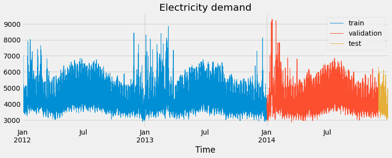

```python
# Time series plot
# ==============================================================================
fig, ax = plt.subplots(figsize=(12, 4))
data_train.Demand.plot(ax=ax, label='train', linewidth=1)
data_val.Demand.plot(ax=ax, label='validation', linewidth=1)
data_test.Demand.plot(ax=ax, label='test', linewidth=1)
ax.set_title('Electricity demand')
ax.legend();
```

The above graph shows that electricity demand has annual seasonality. There is an increase centered on July and very accentuated demand peaks between January and March.

# Section of the time series

Due to the variance of the time series, it is not possible to appreciate with a single chart the possible intraday pattern.

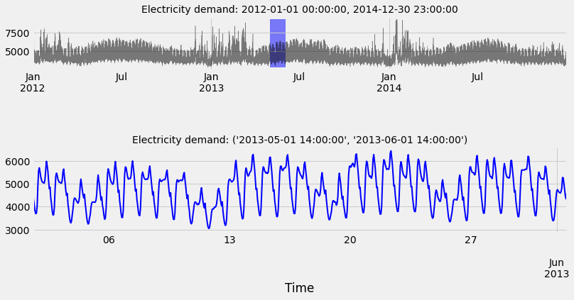

```python
#Zooming time series chart
# ==============================================================================
zoom = ('2013-05-01 14:00:00','2013-06-01 14:00:00')

fig = plt.figure(figsize=(12, 6))
grid = plt.GridSpec(nrows=8, ncols=1, hspace=0.6, wspace=0)

main_ax = fig.add_subplot(grid[1:3, :])
zoom_ax = fig.add_subplot(grid[5:, :])

data.Demand.plot(ax=main_ax, c='black', alpha=0.5, linewidth=0.5)
min_y = min(data.Demand)
max_y = max(data.Demand)
main_ax.fill_between(zoom, min_y, max_y, facecolor='blue', alpha=0.5, zorder=0)
main_ax.set_xlabel('')

data.loc[zoom[0]: zoom[1]].Demand.plot(ax=zoom_ax, color='blue', linewidth=2)

main_ax.set_title(f'Electricity demand: {data.index.min()}, {data.index.max()}', fontsize=14)
zoom_ax.set_title(f'Electricity demand: {zoom}', fontsize=14)
plt.subplots_adjust(hspace=1)
```

When zooming in on the time series, a clear weekly seasonality is evident, with higher consumption during the work week (Monday to Friday) and lower consumption on weekends. It is also observed that there is a clear correlation between the consumption of one day and that of the previous day.

# Annual, weekly and daily seasonality

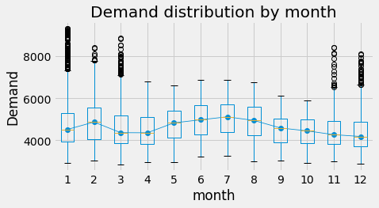

```python
# Boxplot for annual seasonality
# ==============================================================================
fig, ax = plt.subplots(figsize=(7, 3.5))
data['month'] = data.index.month
data.boxplot(column='Demand', by='month', ax=ax,)
data.groupby('month')['Demand'].median().plot(style='o-', linewidth=0.8, ax=ax)
ax.set_ylabel('Demand')
ax.set_title('Demand distribution by month')
fig.suptitle('');
```

It is observed that there is an annual seasonality, with higher (median) demand values in June, July, and August, and with high demand peaks in November, December, January, February, and March.

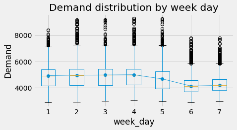

```python
# Boxplot for weekly seasonality
# ==============================================================================
fig, ax = plt.subplots(figsize=(7, 3.5))
data['week_day'] = data.index.day_of_week + 1
data.boxplot(column='Demand', by='week_day', ax=ax)
data.groupby('week_day')['Demand'].median().plot(style='o-', linewidth=0.8, ax=ax)
ax.set_ylabel('Demand')
ax.set_title('Demand distribution by week day')
fig.suptitle('');
```

Weekly seasonality shows lower demand values during the weekend.

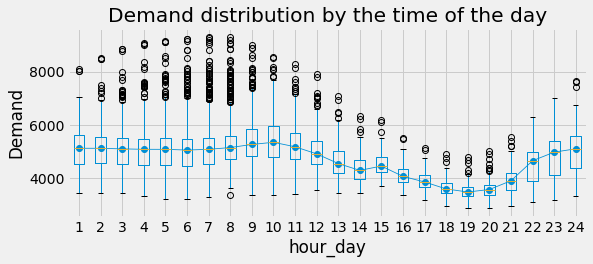

```python
# Boxplot for daily seasonality
# ==============================================================================
fig, ax = plt.subplots(figsize=(9, 3.5))
data['hour_day'] = data.index.hour + 1
data.boxplot(column='Demand', by='hour_day', ax=ax)
data.groupby('hour_day')['Demand'].median().plot(style='o-', linewidth=0.8, ax=ax)
ax.set_ylabel('Demand')
ax.set_title('Demand distribution by the time of the day')
fig.suptitle('');
```

There is also a daily seasonality, with demand decreasing between 16:00 and 21:00 hours.

# Holidays and non-holiday days

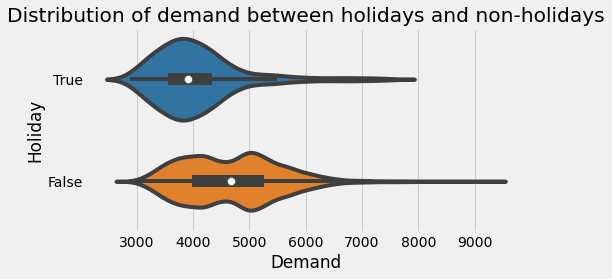

```python
# Violinplot
# ==============================================================================
fig, ax = plt.subplots(nrows=1, ncols=1, figsize=(7, 3.5))
sns.violinplot(
    x       = 'Demand',
    y       = 'Holiday',
    data    = data.assign(Holiday = data.Holiday.astype(str)),
    palette = 'tab10',
    ax      = ax
)
ax.set_title('Distribution of demand between holidays and non-holidays')
ax.set_xlabel('Demand')
ax.set_ylabel('Holiday');
```

Holidays tend to have lower consumption.

# EDA - Temperature

Monthly Temperature in Australia from 2012 to 2015

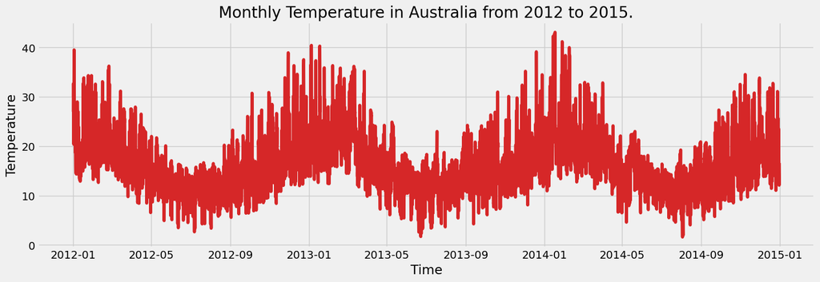

```python
# Draw Plot
def plot_data(data, x, y, title="", xlabel='Time', ylabel='Temperature', dpi=100):
    plt.figure(figsize=(16,5), dpi=dpi)
    plt.plot(x, y, color='tab:red')
    plt.gca().set(title=title, xlabel=xlabel, ylabel=ylabel)
    plt.show()

plot_data(data, x=data.index, y=data.Temperature, title='Monthly Temperature in Australia from 2012 to 2015.')
```

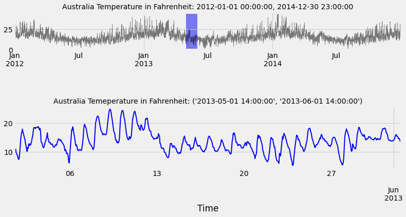

```python
#Zooming time series chart
# ==============================================================================
zoom = ('2013-05-01 14:00:00','2013-06-01 14:00:00')

fig = plt.figure(figsize=(12, 6))
grid = plt.GridSpec(nrows=8, ncols=1, hspace=0.6, wspace=0)

main_ax = fig.add_subplot(grid[1:3, :])
zoom_ax = fig.add_subplot(grid[5:, :])

data.Temperature.plot(ax=main_ax, c='black', alpha=0.5, linewidth=0.5)
min_y = min(data.Temperature)
max_y = max(data.Temperature)
main_ax.fill_between(zoom, min_y, max_y, facecolor='blue', alpha=0.5, zorder=0)
main_ax.set_xlabel('')

data.loc[zoom[0]: zoom[1]].Temperature.plot(ax=zoom_ax, color='blue', linewidth=2)

main_ax.set_title(f'Australia Temperature in Fahrenheit: {data.index.min()}, {data.index.max()}', fontsize=14)
zoom_ax.set_title(f'Australia Temeperature in Fahrenheit: {zoom}', fontsize=14)
plt.subplots_adjust(hspace=1)
```

When zooming in on the time series, a weekly seasonality of temperature is not consistent it varies depending on the week, with higher consumption during the second work week (Monday to Friday) and lower consumption on fourth week. It is also observed that there is no clear correlation between the consumption of one day and that of the previous day.

# Annual, weekly and daily temperature in Australia

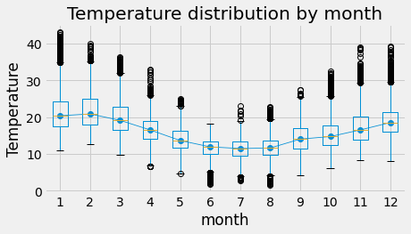

```python
# Boxplot for annual seasonality
# ==============================================================================
fig, ax = plt.subplots(figsize=(7, 3.5))
data['month'] = data.index.month
data.boxplot(column='Temperature', by='month', ax=ax,)
data.groupby('month')['Temperature'].median().plot(style='o-', linewidth=0.8, ax=ax)
ax.set_ylabel('Temperature')
ax.set_title('Temperature distribution by month')
fig.suptitle('');
```

It is observed that there is an annual seasonality in temperature, with lower (median) temperature in June, July, and August, and with high demand peaks in November, December, January, and February.

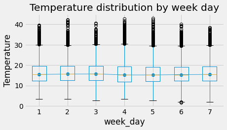

```python
# Boxplot for weekly seasonality
# ==============================================================================
fig, ax = plt.subplots(figsize=(7, 3.5))
data['week_day'] = data.index.day_of_week + 1
data.boxplot(column='Temperature', by='week_day', ax=ax)
data.groupby('week_day')['Temperature'].median().plot(style='o-', linewidth=0.8, ax=ax)
ax.set_ylabel('Temperature')
ax.set_title('Temperature distribution by week day')
fig.suptitle('');
```

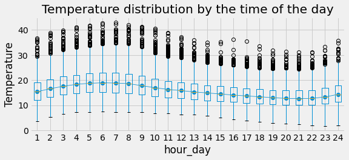

```python
# Boxplot for daily seasonality
# ==============================================================================
fig, ax = plt.subplots(figsize=(9, 3.5))
data['hour_day'] = data.index.hour + 1
data.boxplot(column='Temperature', by='hour_day', ax=ax)
data.groupby('hour_day')['Temperature'].median().plot(style='o-', linewidth=0.8, ax=ax)
ax.set_ylabel('Temperature')
ax.set_title('Temperature distribution by the time of the day')
fig.suptitle('');
```

There is also a daily seasonality, with temperature slightly decreasing between 19:00 and 21:00 hours.

```python
print(data[['Demand', 'Temperature']].corr(method='spearman'))

# Print the correlation between Demand and Temperature columns
```

```
               Demand  Temperature
Demand       1.000000     0.113958
Temperature  0.113958     1.000000
```

The correlation matrix above indicates No relationship between Elecctricity Demand and the Temperature in Victoria Australia.

Verify Correlation via an Heatmap

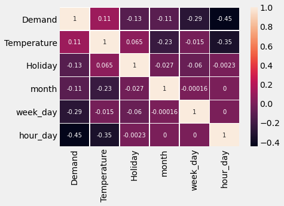

```python
corr_data = data.corr(method='spearman')

# Customize the heatmap of the corr_meat correlation matrix
sns.heatmap(corr_data,
           annot=True,
           linewidths=0.4,
           annot_kws={'size': 10});

plt.xticks(rotation=90);
plt.yticks(rotation=0);
```

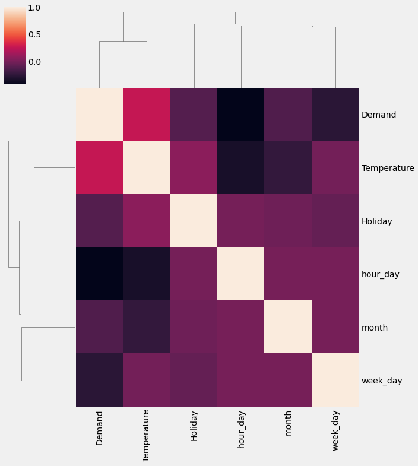

```python
corr_data = data.corr(method='pearson')

# Customize the heatmap of the corr_meat correlation matrix
fig = sns.clustermap(corr_data,
               row_cluster=True,
               col_cluster=True,
               figsize=(10, 10));

plt.setp(fig.ax_heatmap.xaxis.get_majorticklabels(), rotation=90);
plt.setp(fig.ax_heatmap.yaxis.get_majorticklabels(), rotation=0);
```

# Autocorrelation plots

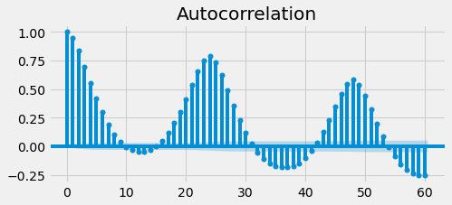

```python
# Autocorrelation plot
# ==============================================================================
fig, ax = plt.subplots(figsize=(7, 3))
plot_acf(data.Demand, ax=ax, lags=60)
plt.show()
```

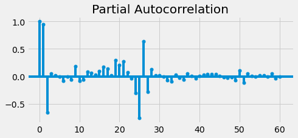

```python
# Partial autocorrelation plot
# ==============================================================================
fig, ax = plt.subplots(figsize=(7, 3))
plot_pacf(data.Demand, ax=ax, lags=60)
plt.show()
```

The autocorrelation and partial autocorrelation plots show a clear association between one hour's demand and previous hours, as well as between one hour's demand and the same hour's demand on previous days. This type of correlation is an indication that autoregressive models can work well.

# Recursive autoregressive forecasting

A recursive autoregressive model (ForecasterAutoreg) is created and trained from a linear regression model with a Ridge penalty and a time window of 24 lags. The latter means that, for each prediction, the demand values of the previous 24 hours are used as predictors.

# Forecaster training

```python
# Create and train forecaster
# ==============================================================================
forecaster = ForecasterAutoreg(
                regressor = make_pipeline(StandardScaler(), Ridge()),
                lags      = 24
             )

forecaster.fit(y=data.loc[:end_validation, 'Demand'])
forecaster
```

```
=================
ForecasterAutoreg
=================
Regressor: Pipeline(steps=[('standardscaler', StandardScaler()), ('ridge', Ridge())])
Lags: [ 1  2  3  4  5  6  7  8  9 10 11 12 13 14 15 16 17 18 19 20 21 22 23 24]
Window size: 24
Included exogenous: False
Type of exogenous variable: None
Exogenous variables names: None
Training range: [Timestamp('2012-01-01 00:00:00'), Timestamp('2014-11-30 23:00:00')]
Training index type: DatetimeIndex
Training index frequency: H
Regressor parameters: {'standardscaler__copy': True, 'standardscaler__with_mean': True, 'standardscaler__with_std': True, 'ridge__alpha': 1.0, 'ridge__copy_X': True, 'ridge__fit_intercept': True, 'ridge__max_iter': None, 'ridge__normalize': 'deprecated', 'ridge__positive': False, 'ridge__random_stat…
Creation date: 2022-06-06 00:07:30
Last fit date: 2022-06-06 00:07:31
Skforecast version: 0.4.3
```

# Backtest

How the model would have behaved if it had been trained with the data from 2012-01-01 00:00 to 2014-11-30 23:59 and then, at 23:59 each day, the following 24 hours were predicted is evaluated. This type of evaluation, known as Backtesting, can be easily implemented with the function backtesting_forecaster(). This function returns, in addition to the predictions, an error metric.

```python
# Backtest
# ==============================================================================
metric, predictions = backtesting_forecaster(
                            forecaster = forecaster,
                            y          = data.Demand,
                            initial_train_size = len(data.loc[:end_validation]),
                            fixed_train_size   = False,
                            steps      = 24,
                            metric     = 'mean_absolute_error',
                            refit      = False,
                            verbose    = True
                       )
```

```
Information of backtesting process
----------------------------------
Number of observations used for initial training or as initial window: 25560
Number of observations used for backtesting: 720
    Number of folds: 30
    Number of steps per fold: 24

Data partition in fold: 0
    Training:   2012-01-01 00:00:00 -- 2014-11-30 23:00:00
    Validation: 2014-12-01 00:00:00 -- 2014-12-01 23:00:00
Data partition in fold: 1
    Training:   2012-01-01 00:00:00 -- 2014-11-30 23:00:00
    Validation: 2014-12-02 00:00:00 -- 2014-12-02 23:00:00
Data partition in fold: 2
    Training:   2012-01-01 00:00:00 -- 2014-11-30 23:00:00
    Validation: 2014-12-03 00:00:00 -- 2014-12-03 23:00:00
Data partition in fold: 3
    Training:   2012-01-01 00:00:00 -- 2014-11-30 23:00:00
    Validation: 2014-12-04 00:00:00 -- 2014-12-04 23:00:00
Data partition in fold: 4
    Training:   2012-01-01 00:00:00 -- 2014-11-30 23:00:00
    Validation: 2014-12-05 00:00:00 -- 2014-12-05 23:00:00
Data partition in fold: 5
    Training:   2012-01-01 00:00:00 -- 2014-11-30 23:00:00
    Validation: 2014-12-06 00:00:00 -- 2014-12-06 23:00:00
Data partition in fold: 6
    Training:   2012-01-01 00:00:00 -- 2014-11-30 23:00:00
    Validation: 2014-12-07 00:00:00 -- 2014-12-07 23:00:00
Data partition in fold: 7
    Training:   2012-01-01 00:00:00 -- 2014-11-30 23:00:00
    Validation: 2014-12-08 00:00:00 -- 2014-12-08 23:00:00
Data partition in fold: 8
    Training:   2012-01-01 00:00:00 -- 2014-11-30 23:00:00
    Validation: 2014-12-09 00:00:00 -- 2014-12-09 23:00:00
Data partition in fold: 9
    Training:   2012-01-01 00:00:00 -- 2014-11-30 23:00:00
    Validation: 2014-12-10 00:00:00 -- 2014-12-10 23:00:00
Data partition in fold: 10
    Training:   2012-01-01 00:00:00 -- 2014-11-30 23:00:00
    Validation: 2014-12-11 00:00:00 -- 2014-12-11 23:00:00
```

[output cut: 42 more lines]

```
Data partition in fold: 25
    Training:   2012-01-01 00:00:00 -- 2014-11-30 23:00:00
    Validation: 2014-12-26 00:00:00 -- 2014-12-26 23:00:00
Data partition in fold: 26
    Training:   2012-01-01 00:00:00 -- 2014-11-30 23:00:00
    Validation: 2014-12-27 00:00:00 -- 2014-12-27 23:00:00
Data partition in fold: 27
    Training:   2012-01-01 00:00:00 -- 2014-11-30 23:00:00
    Validation: 2014-12-28 00:00:00 -- 2014-12-28 23:00:00
Data partition in fold: 28
    Training:   2012-01-01 00:00:00 -- 2014-11-30 23:00:00
    Validation: 2014-12-29 00:00:00 -- 2014-12-29 23:00:00
Data partition in fold: 29
    Training:   2012-01-01 00:00:00 -- 2014-11-30 23:00:00
    Validation: 2014-12-30 00:00:00 -- 2014-12-30 23:00:00
```

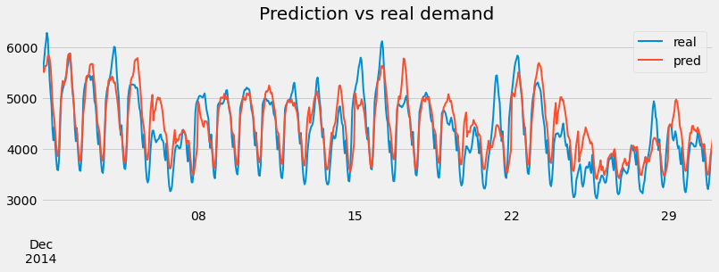

```python
# Plot
# ==============================================================================
fig, ax = plt.subplots(figsize=(12, 3.5))
data.loc[predictions.index, 'Demand'].plot(ax=ax, linewidth=2, label='real')
predictions.plot(linewidth=2, label='prediction', ax=ax)
ax.set_title('Prediction vs real demand')
ax.legend();
```

```python
# Backtest error
# ==============================================================================
print(f'Backtest error: {metric}')
```

```
Backtest error: 289.5191503038139
```

# Hyperparameter tuning

In the trained ForecasterAutoreg object, the first 24 lags and a Ridge model with the default hyperparameters have been utilized. However, there is no basis why these values are the most appropriate.

To recognize the best combination of lags and hyperparameters, a Grid Search with validation by Backtesting is employed. This process contains training a model with numerous combinations of hyperparameters and lags and evaluating its predictive capacity. In the search process, it is significant to analyze the models using only the validation data and not to include the test data, which are used only to evaluate the final model.

```python
# Hyperparameter Grid search
# ==============================================================================
forecaster = ForecasterAutoreg(
                    regressor = make_pipeline(StandardScaler(), Ridge()),
                    lags      = 24 # This value will be replaced in the grid search
             )

# Lags used as predictors
lags_grid = [5, 24, [1, 2, 3, 23, 24, 25, 47, 48, 49]]

# Regressor's hyperparameters
param_grid = {'ridge__alpha': np.logspace(-3, 5, 10)}

results_grid = grid_search_forecaster(
                        forecaster  = forecaster,
                        y           = data.loc[:end_validation, 'Demand'],
                        param_grid  = param_grid,
                        lags_grid   = lags_grid,
                        steps       = 24,
                        metric      = 'mean_absolute_error',
                        refit       = False,
                        initial_train_size = len(data[:end_train]),
                        fixed_train_size   = False,
                        return_best = True,
                        verbose     = False
                 )
```

```
Number of models compared: 30
```

```
`Forecaster` refitted using the best-found lags and parameters, and the whole data set:
  Lags: [ 1  2  3 23 24 25 47 48 49]
  Parameters: {'ridge__alpha': 215.44346900318823}
  Backtesting metric: 257.8431725056719
```

```python
# Grid Search results
# ==============================================================================
results_grid
```

|  | lags | params | metric | ridge__alpha |
| --- | --- | --- | --- | --- |
| 26 | [1, 2, 3, 23, 24, 25, 47, 48, 49] | {'ridge__alpha': 215.44346900318823} | 257.843173 | 215.443469 |
| 25 | [1, 2, 3, 23, 24, 25, 47, 48, 49] | {'ridge__alpha': 27.825594022071257} | 290.555205 | 27.825594 |
| 24 | [1, 2, 3, 23, 24, 25, 47, 48, 49] | {'ridge__alpha': 3.593813663804626} | 306.631981 | 3.593814 |
| 23 | [1, 2, 3, 23, 24, 25, 47, 48, 49] | {'ridge__alpha': 0.46415888336127775} | 309.393349 | 0.464159 |
| 22 | [1, 2, 3, 23, 24, 25, 47, 48, 49] | {'ridge__alpha': 0.05994842503189409} | 309.776084 | 0.059948 |
| 21 | [1, 2, 3, 23, 24, 25, 47, 48, 49] | {'ridge__alpha': 0.007742636826811269} | 309.825962 | 0.007743 |
| 20 | [1, 2, 3, 23, 24, 25, 47, 48, 49] | {'ridge__alpha': 0.001} | 309.832410 | 0.001000 |
| 10 | [1, 2, 3, 4, 5, 6, 7, 8, 9, 10, 11, 12, 13, 14... | {'ridge__alpha': 0.001} | 325.041129 | 0.001000 |
| 11 | [1, 2, 3, 4, 5, 6, 7, 8, 9, 10, 11, 12, 13, 14... | {'ridge__alpha': 0.007742636826811269} | 325.043579 | 0.007743 |
| 12 | [1, 2, 3, 4, 5, 6, 7, 8, 9, 10, 11, 12, 13, 14... | {'ridge__alpha': 0.05994842503189409} | 325.062536 | 0.059948 |
| 13 | [1, 2, 3, 4, 5, 6, 7, 8, 9, 10, 11, 12, 13, 14... | {'ridge__alpha': 0.46415888336127775} | 325.208755 | 0.464159 |
| 14 | [1, 2, 3, 4, 5, 6, 7, 8, 9, 10, 11, 12, 13, 14... | {'ridge__alpha': 3.593813663804626} | 326.307375 | 3.593814 |
| 15 | [1, 2, 3, 4, 5, 6, 7, 8, 9, 10, 11, 12, 13, 14... | {'ridge__alpha': 27.825594022071257} | 333.395125 | 27.825594 |
| 27 | [1, 2, 3, 23, 24, 25, 47, 48, 49] | {'ridge__alpha': 1668.1005372000557} | 356.547658 | 1668.100537 |
| 16 | [1, 2, 3, 4, 5, 6, 7, 8, 9, 10, 11, 12, 13, 14... | {'ridge__alpha': 215.44346900318823} | 360.841496 | 215.443469 |
| 17 | [1, 2, 3, 4, 5, 6, 7, 8, 9, 10, 11, 12, 13, 14... | {'ridge__alpha': 1668.1005372000557} | 396.342247 | 1668.100537 |
| 18 | [1, 2, 3, 4, 5, 6, 7, 8, 9, 10, 11, 12, 13, 14... | {'ridge__alpha': 12915.496650148827} | 421.002019 | 12915.496650 |
| 28 | [1, 2, 3, 23, 24, 25, 47, 48, 49] | {'ridge__alpha': 12915.496650148827} | 443.551888 | 12915.496650 |
| 19 | [1, 2, 3, 4, 5, 6, 7, 8, 9, 10, 11, 12, 13, 14... | {'ridge__alpha': 100000.0} | 540.659659 | 100000.000000 |
| 29 | [1, 2, 3, 23, 24, 25, 47, 48, 49] | {'ridge__alpha': 100000.0} | 545.502052 | 100000.000000 |
| 7 | [1, 2, 3, 4, 5] | {'ridge__alpha': 1668.1005372000557} | 611.236033 | 1668.100537 |
| 0 | [1, 2, 3, 4, 5] | {'ridge__alpha': 0.001} | 612.352191 | 0.001000 |
| 1 | [1, 2, 3, 4, 5] | {'ridge__alpha': 0.007742636826811269} | 612.352531 | 0.007743 |
| 2 | [1, 2, 3, 4, 5] | {'ridge__alpha': 0.05994842503189409} | 612.355162 | 0.059948 |
| 3 | [1, 2, 3, 4, 5] | {'ridge__alpha': 0.46415888336127775} | 612.375445 | 0.464159 |
| 4 | [1, 2, 3, 4, 5] | {'ridge__alpha': 3.593813663804626} | 612.528081 | 3.593814 |
| 5 | [1, 2, 3, 4, 5] | {'ridge__alpha': 27.825594022071257} | 613.477722 | 27.825594 |
| 6 | [1, 2, 3, 4, 5] | {'ridge__alpha': 215.44346900318823} | 615.109317 | 215.443469 |
| 8 | [1, 2, 3, 4, 5] | {'ridge__alpha': 12915.496650148827} | 625.105850 | 12915.496650 |
| 9 | [1, 2, 3, 4, 5] | {'ridge__alpha': 100000.0} | 681.830571 | 100000.000000 |

The best results are obtained by using the lags [1, 2, 3, 23, 24, 25, 47, 48, 49] and a Ridge configuration {'alpha': 215.44}. By specifying return_best = True in the grid_search_forecaster() function, at the end of the process, the forecaster object is automatically retrained with the best configuration found and the complete dataset (train + validation).

```python
forecaster
```

```
=================
ForecasterAutoreg
=================
Regressor: Pipeline(steps=[('standardscaler', StandardScaler()),
                ('ridge', Ridge(alpha=215.44346900318823))])
Lags: [ 1  2  3 23 24 25 47 48 49]
Window size: 49
Included exogenous: False
Type of exogenous variable: None
Exogenous variables names: None
Training range: [Timestamp('2012-01-01 00:00:00'), Timestamp('2014-11-30 23:00:00')]
Training index type: DatetimeIndex
Training index frequency: H
Regressor parameters: {'standardscaler__copy': True, 'standardscaler__with_mean': True, 'standardscaler__with_std': True, 'ridge__alpha': 215.44346900318823, 'ridge__copy_X': True, 'ridge__fit_intercept': True, 'ridge__max_iter': None, 'ridge__normalize': 'deprecated', 'ridge__positive': False, 'rid…
Creation date: 2022-06-06 00:07:32
Last fit date: 2022-06-06 00:08:21
Skforecast version: 0.4.3
```

# Backtest with test data

Once the best model has been identified and trained, its error in predicting the test data is calculated.

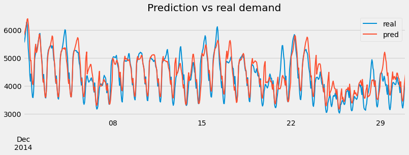

```python
# Backtest final model
# ==============================================================================
metric, predictions = backtesting_forecaster(
                            forecaster = forecaster,
                            y          = data.Demand,
                            initial_train_size = len(data[:end_validation]),
                            fixed_train_size   = False,
                            steps      = 24,
                            metric     = 'mean_absolute_error',
                            refit      = False,
                            verbose    = False
                      )

fig, ax = plt.subplots(figsize=(12, 3.5))
data.loc[predictions.index, 'Demand'].plot(linewidth=2, label='real', ax=ax)
predictions.plot(linewidth=2, label='prediction', ax=ax)
ax.set_title('Prediction vs real demand')
ax.legend();
```

```python
# Error backtest
# ==============================================================================
print(f'Backtest error: {metric}')
```

```
Backtest error: 251.93996461684006
```

After optimizing lags and hyperparameters, I observed that the prediction error was reduced from 289.5 to 251.9.

# Prediction intervals

A prediction interval defines the interval within which the true value of "y" can be expected to be found with a given probability. Data Scientist list multiple ways to estimate prediction intervals, most of which require that the residuals (errors) of the model are normally distributed. When this property cannot be assumed, bootstrapping can be resorted to, which only assumes that the residuals are uncorrelated. This is the method used in the Skforecast library for the ForecasterAutoreg and ForecasterAutoregCustom type models.

```python
# Backtest with test data and prediction intervals
# ==============================================================================
metric, predictions = backtesting_forecaster(
                            forecaster = forecaster,
                            y          = data.Demand,
                            initial_train_size = len(data.Demand[:end_validation]),
                            fixed_train_size   = False,
                            steps      = 24,
                            metric     = 'mean_absolute_error',
                            interval            = [10, 90],
                            n_boot              = 500,
                            in_sample_residuals = True,
                            verbose             = False
                       )

print('Backtesting metric:', metric)
predictions.head(10)
```

```
Backtesting metric: 251.93996461684006
```

|  | pred | lower_bound | upper_bound |
| --- | --- | --- | --- |
| 2014-12-01 00:00:00 | 5727.876561 | 5598.911947 | 5849.678211 |
| 2014-12-01 01:00:00 | 5802.876139 | 5599.270390 | 5974.888764 |
| 2014-12-01 02:00:00 | 5880.047528 | 5619.841591 | 6113.916977 |
| 2014-12-01 03:00:00 | 5953.541637 | 5657.437015 | 6240.035968 |
| 2014-12-01 04:00:00 | 6048.740321 | 5697.793533 | 6343.068708 |
| 2014-12-01 05:00:00 | 6137.445368 | 5765.494199 | 6452.822013 |
| 2014-12-01 06:00:00 | 6261.838234 | 5883.973887 | 6573.446149 |
| 2014-12-01 07:00:00 | 6386.619471 | 6007.654524 | 6724.388773 |
| 2014-12-01 08:00:00 | 6402.610840 | 5993.715349 | 6803.544231 |
| 2014-12-01 09:00:00 | 6244.943528 | 5829.013106 | 6631.480809 |

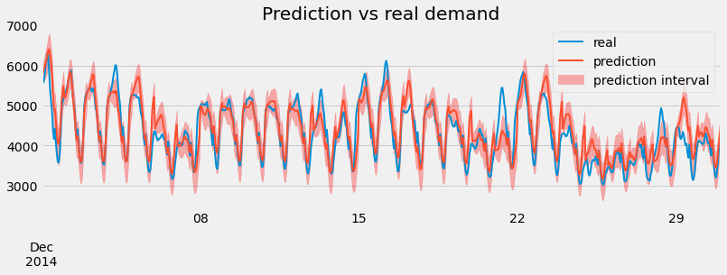

```python
# Plot
# ==============================================================================
fig, ax = plt.subplots(figsize=(12, 3.5))
data.loc[predictions.index, 'Demand'].plot(linewidth=2, label='real', ax=ax)
predictions.iloc[:, 0].plot(linewidth=2, label='prediction', ax=ax)
ax.set_title('Prediction vs real demand')
ax.fill_between(
    predictions.index,
    predictions.iloc[:, 1],
    predictions.iloc[:, 2],
    alpha = 0.3,
    color = 'red',
    label = 'prediction interval'
)
ax.legend();
```

```python
# Predicted interval coverage
# ==============================================================================
inside_interval = np.where(
                     (data.loc[end_validation:, 'Demand'] >= predictions["lower_bound"]) & \
                     (data.loc[end_validation:, 'Demand'] <= predictions["upper_bound"]),
                     True,
                     False
                  )

coverage = inside_interval.mean()
print(f"Predicted interval coverage: {round(100*coverage, 2)} %")
```

```
Predicted interval coverage: 79.03 %
```

The predicted interval has a lower coverage than expected (80%). It may be due to the marked high error made by the model for days 21, 24, and 25. These days are within the Christmas holiday period, usually characterized by a different consumption behavior than the rest of the month.